# Temperature and VPD effects on P. xanthii germination

Investigating the effect of temperature and VPD on *Podosphera xanthii* conida in cucurbits

Paul Melloy (The University of Queensland)https://uq.edu.au  
2022-03-15

Load R libraries required for analysis

```r
library(data.table)
library(mgcv)
library(lme4)
library(ggplot2)
```

Import the clean data

```r
g_tm <- fread("cache/germination_temperature.csv")
g_vpd <- fread("cache/germination_response_to_vpd.csv")
```

## Impact of Temperature on *P. xanthii* germination

Peek at the data

```r
head(g_tm)
```

```
   Tm i_period leaf germ_conidia non_germ_conidia
1: 17       12   L1            7               93
2: 17       12   L1            9               91
3: 17       12   L2            5               95
4: 17       12   L2           10               90
5: 17       24   L1           17               83
6: 17       24   L1           14               86
```

```r
str(g_tm)
```

```
Classes 'data.table' and 'data.frame':  96 obs. of  5 variables:
 $ Tm              : int  17 17 17 17 17 17 17 17 17 17 ...
 $ i_period        : int  12 12 12 12 24 24 24 24 36 36 ...
 $ leaf            : chr  "L1" "L1" "L2" "L2" ...
 $ germ_conidia    : int  7 9 5 10 17 14 16 13 23 21 ...
 $ non_germ_conidia: int  93 91 95 90 83 86 84 87 77 79 ...
 - attr(*, ".internal.selfref")=<externalptr>
```

### Visualise the raw data  
Let’s plot the data over time

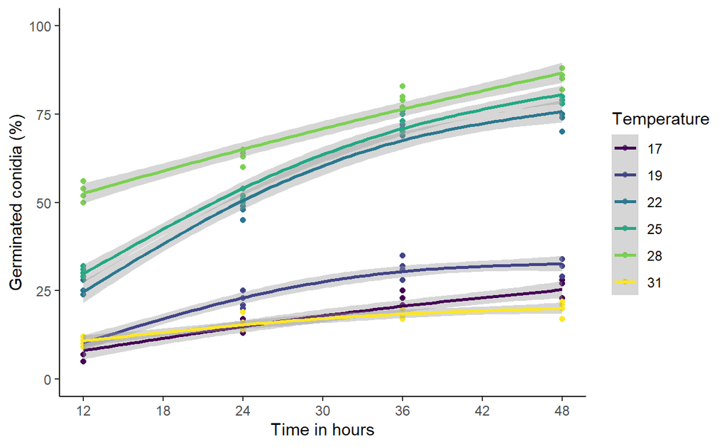

```r
g_tm |>
   ggplot(aes(x = i_period, y = germ_conidia, colour = as.factor(Tm))) +
   geom_point()+
   geom_smooth(method = "gam",formula = y ~ s(x, k = 3))+
   scale_color_viridis_d()+
   xlab("Time in hours")+
   ylab("Germinated conidia (%)")+
   labs(colour = "Temperature")+
   theme_classic()+
   scale_x_continuous(limits = c(12,48), breaks = c(12,18,24,30,36,42,48))+
   scale_y_continuous(limits = c(0,100), n.breaks = 5)
```

Now lets plot germination over temperature separating by infection period.

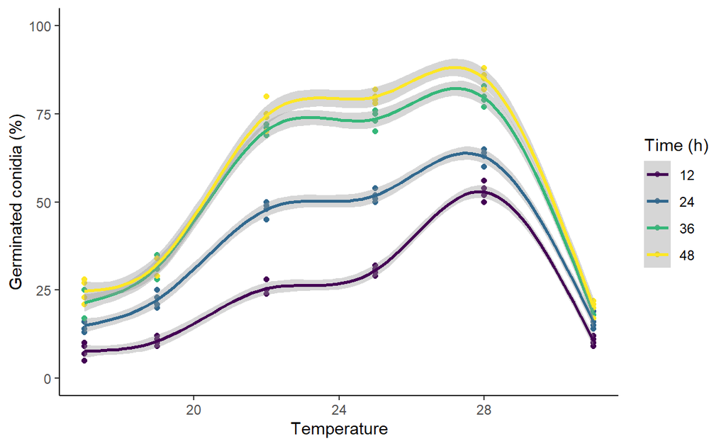

```r
g_tm |>
   ggplot(aes(x = Tm, y = germ_conidia, colour = as.factor(i_period))) +
   geom_point()+
   geom_smooth(method = "gam",formula = y ~ s(x, k = 6))+
   scale_color_viridis_d()+
   xlab("Temperature")+
   ylab("Germinated conidia (%)")+
   labs(colour = "Time (h)")+
   theme_classic()+
   #scale_x_continuous(limits = c(12,48), breaks = c(12,18,24,30,36,42,48))+
   scale_y_continuous(limits = c(0,100), n.breaks = 5)
```

Lets further evaluate this fit. However instead of fitting a temperature as a separate random effect, as depicted in the above plot, we will define temperature as a separate continuous predictor that may or may not interact with infection period.

```r
m1 <- gam(cbind(germ_conidia, non_germ_conidia) ~ s(i_period, k=3) + s(Tm, k =4),
          data = g_tm,
          family = "binomial")
summary(m1)
```

```
Family: binomial
Link function: logit

Formula:
cbind(germ_conidia, non_germ_conidia) ~ s(i_period, k = 3) +
    s(Tm, k = 4)

Parametric coefficients:
            Estimate Std. Error z value Pr(>|z|)
(Intercept) -0.51709    0.02445  -21.15   <2e-16 ***
---
Signif. codes:  0 '***' 0.001 '**' 0.01 '*' 0.05 '.' 0.1 ' ' 1

Approximate significance of smooth terms:
              edf Ref.df Chi.sq p-value
s(i_period) 1.974  1.999    627  <2e-16 ***
s(Tm)       2.995  3.000   1604  <2e-16 ***
---
Signif. codes:  0 '***' 0.001 '**' 0.01 '*' 0.05 '.' 0.1 ' ' 1

R-sq.(adj) =  0.894   Deviance explained = 89.3%
UBRE = 2.2188  Scale est. = 1         n = 96
```

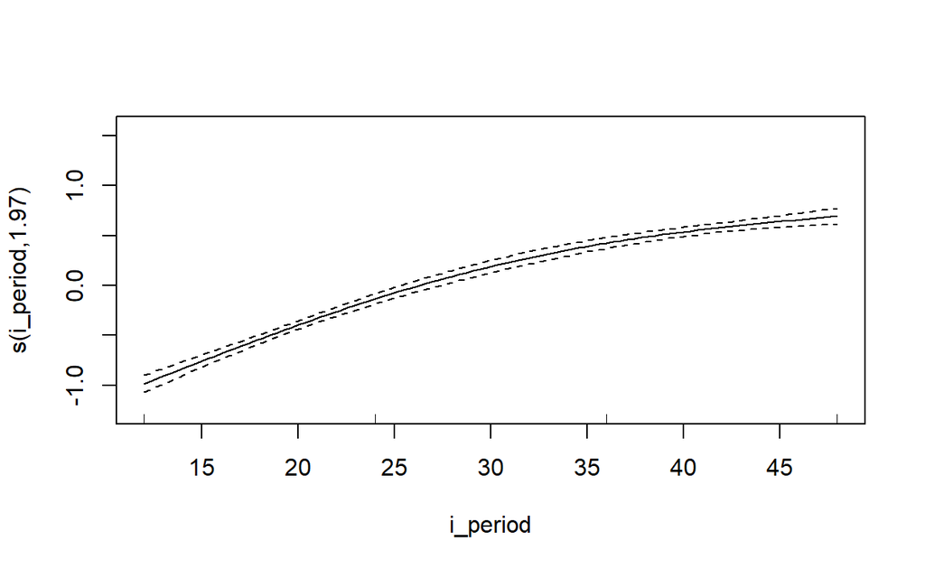

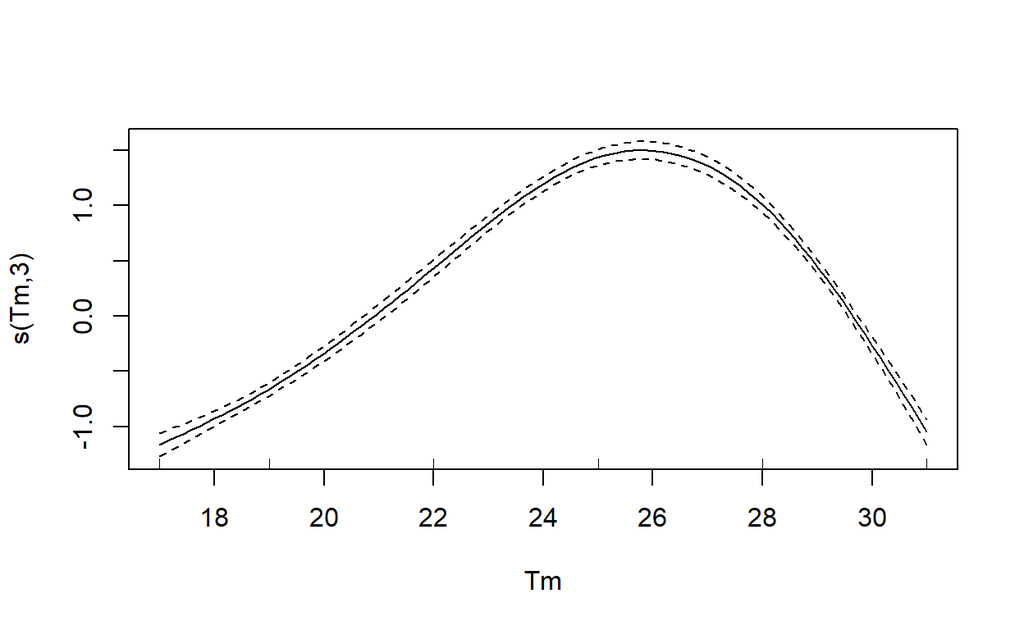

```r
plot(m1)
```

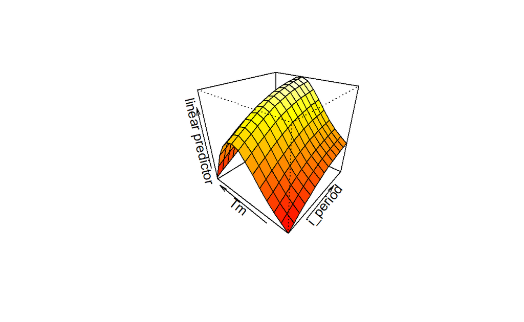

```r
vis.gam(m1,
        theta = -50, # horizontal rotation
        phi = 30, # vertical rotation
        n.grid = max(g_tm$Tm) - min(g_tm$Tm) # grid cells
        )
```

Model two we will investigate whether there is an interaction between temperature and infection period.

```r
m2 <- gam(cbind(germ_conidia, non_germ_conidia) ~ te(i_period, Tm, k = 4),
          data = g_tm,
          family = "binomial")
summary(m2)
```

```
Family: binomial
Link function: logit

Formula:
cbind(germ_conidia, non_germ_conidia) ~ te(i_period, Tm, k = 4)

Parametric coefficients:
            Estimate Std. Error z value Pr(>|z|)
(Intercept) -0.47572    0.02497  -19.05   <2e-16 ***
---
Signif. codes:  0 '***' 0.001 '**' 0.01 '*' 0.05 '.' 0.1 ' ' 1

Approximate significance of smooth terms:
                  edf Ref.df Chi.sq p-value
te(i_period,Tm) 11.91  13.42   1919  <2e-16 ***
---
Signif. codes:  0 '***' 0.001 '**' 0.01 '*' 0.05 '.' 0.1 ' ' 1

R-sq.(adj) =  0.912   Deviance explained = 91.2%
UBRE = 1.8064  Scale est. = 1         n = 96
```

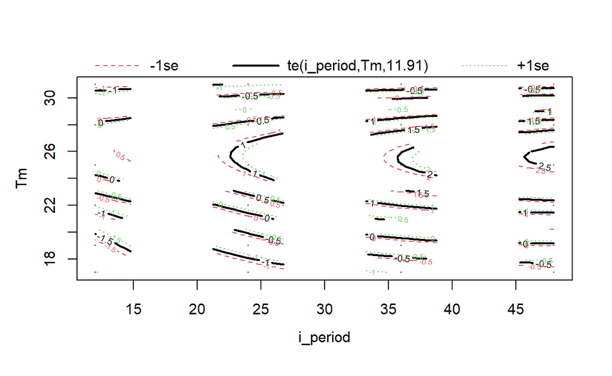

```r
plot(m2)
```

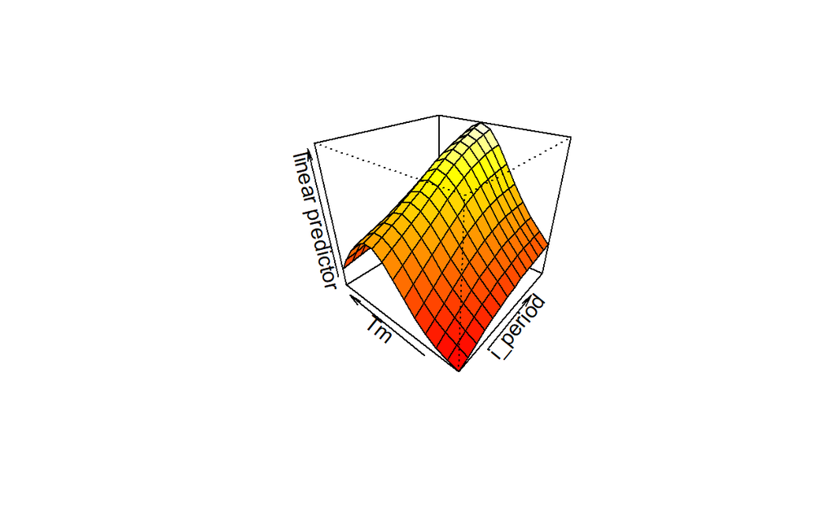

```r
vis.gam(m2,
        theta = -50, # horizontal rotation
        phi = 30, # vertical rotation
        n.grid = max(g_tm$Tm) - min(g_tm$Tm) # grid cells
        )
```

This model shows slightly higher R squared and ‘explained deviance’ values, with a lower UBRE value indicating that model two (`m2`) is the better model.

Lets compare the models against each other.

```r
anova(m1,m2, test = "Chisq")
```

```
Analysis of Deviance Table

Model 1: cbind(germ_conidia, non_germ_conidia) ~ s(i_period, k = 3) +
    s(Tm, k = 4)
Model 2: cbind(germ_conidia, non_germ_conidia) ~ te(i_period, Tm, k = 4)
  Resid. Df Resid. Dev     Df Deviance  Pr(>Chi)
1    90.001     297.07
2    81.582     243.60 8.4188   53.473 1.339e-08 ***
---
Signif. codes:  0 '***' 0.001 '**' 0.01 '*' 0.05 '.' 0.1 ' ' 1
```

This confirms that model two is the better model and explains more of the deviance.

P-splines use a penalised least-square method to fit the model and are better in non-normal distributions. Lets try p splines to see if we can improve the fit.

```r
m3 <- gam(cbind(germ_conidia, non_germ_conidia) ~ s(i_period, k=3) + s(Tm, k =4, bs = "ps"),
          data = g_tm,
          family = "binomial")
summary(m3)
```

```
Family: binomial
Link function: logit

Formula:
cbind(germ_conidia, non_germ_conidia) ~ s(i_period, k = 3) +
    s(Tm, k = 4, bs = "ps")

Parametric coefficients:
            Estimate Std. Error z value Pr(>|z|)
(Intercept) -0.52369    0.02461  -21.28   <2e-16 ***
---
Signif. codes:  0 '***' 0.001 '**' 0.01 '*' 0.05 '.' 0.1 ' ' 1

Approximate significance of smooth terms:
              edf Ref.df Chi.sq p-value
s(i_period) 1.974  1.999  631.5  <2e-16 ***
s(Tm)       2.996  3.000 1655.2  <2e-16 ***
---
Signif. codes:  0 '***' 0.001 '**' 0.01 '*' 0.05 '.' 0.1 ' ' 1

R-sq.(adj) =  0.919   Deviance explained = 91.7%
UBRE = 1.5232  Scale est. = 1         n = 96
```

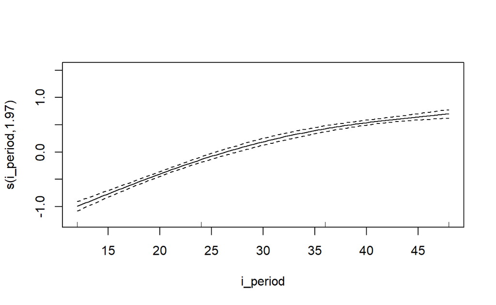

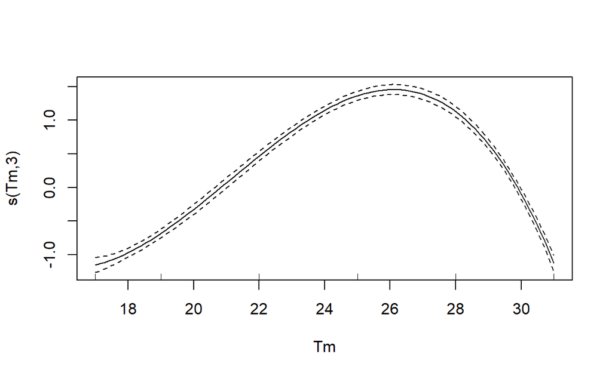

```r
plot(m3)
```

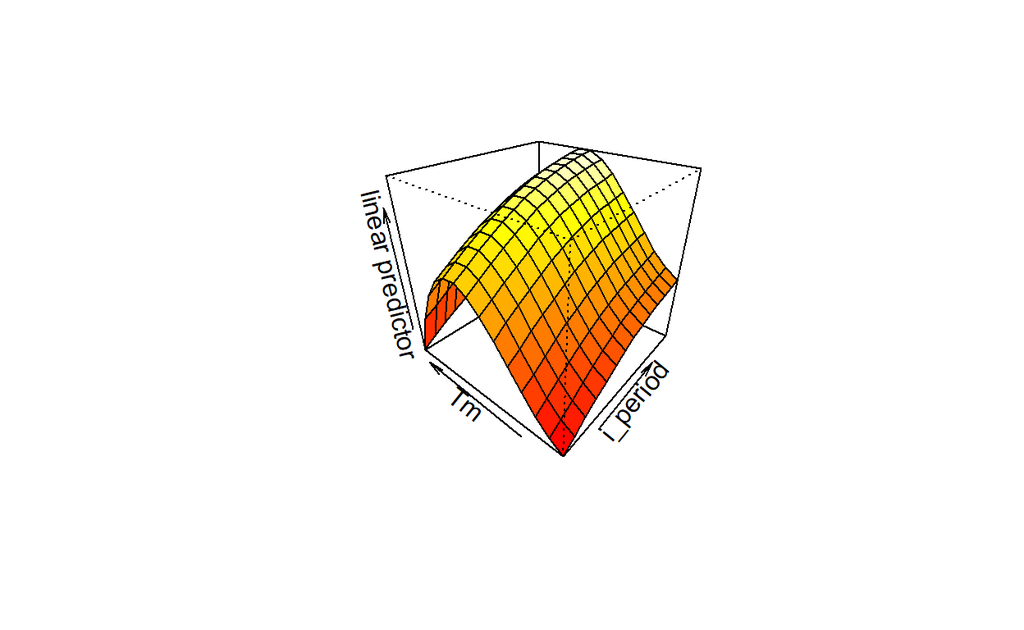

```r
vis.gam(m3,
        theta = -50, # horizontal rotation
        phi = 30, # vertical rotation
        n.grid = max(g_tm$Tm) - min(g_tm$Tm) # grid cells
        )
```

The P-splines have improved the predictive ability of the model with a lower UBRE, improved the R squared value and explained deviance. We can also see that the curve has been shifted slightly up towards 28C.

Lets compare the models two and three to against each other.

```r
anova(m2,m3, test = "Chisq")
```

```
Analysis of Deviance Table

Model 1: cbind(germ_conidia, non_germ_conidia) ~ te(i_period, Tm, k = 4)
Model 2: cbind(germ_conidia, non_germ_conidia) ~ s(i_period, k = 3) +
    s(Tm, k = 4, bs = "ps")
  Resid. Df Resid. Dev      Df Deviance Pr(>Chi)
1    81.582     243.60
2    90.001     230.29 -8.4188   13.308
```

The models show no significant difference therefore we should use the simpler model, model three (`m3`). Model three also shows a better fit to the data.

Next lets see if cyclic versions of the p-splines `"cp"` improve this fit further.

```r
m4 <- gam(cbind(germ_conidia, non_germ_conidia) ~ s(i_period, k=3) + s(Tm, k =4, bs = "cp"),
          data = g_tm,
          family = "binomial")
summary(m4)
```

```
Family: binomial
Link function: logit

Formula:
cbind(germ_conidia, non_germ_conidia) ~ s(i_period, k = 3) +
    s(Tm, k = 4, bs = "cp")

Parametric coefficients:
            Estimate Std. Error z value Pr(>|z|)
(Intercept) -0.53931    0.02499  -21.58   <2e-16 ***
---
Signif. codes:  0 '***' 0.001 '**' 0.01 '*' 0.05 '.' 0.1 ' ' 1

Approximate significance of smooth terms:
              edf Ref.df Chi.sq p-value
s(i_period) 1.974  1.999  637.7  <2e-16 ***
s(Tm)       2.997  3.000 1700.4  <2e-16 ***
---
Signif. codes:  0 '***' 0.001 '**' 0.01 '*' 0.05 '.' 0.1 ' ' 1

R-sq.(adj) =  0.962   Deviance explained = 95.6%
UBRE = 0.39636  Scale est. = 1         n = 96
```

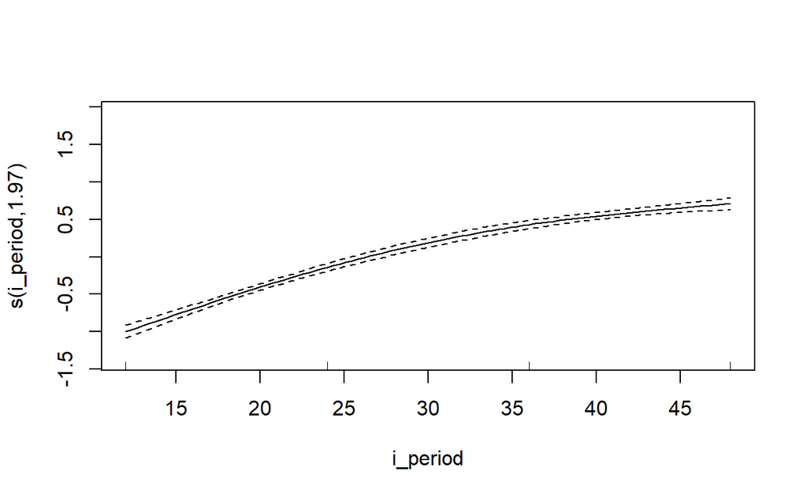

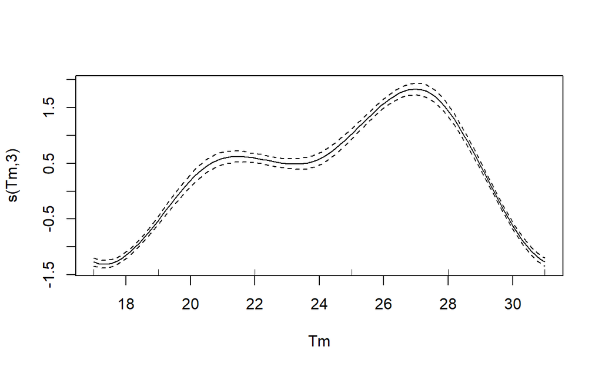

```r
plot(m4)
```

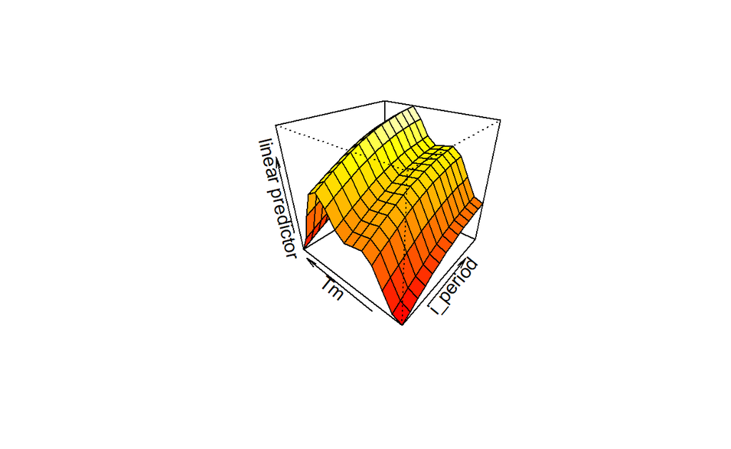

```r
vis.gam(m4,
        theta = -50, # horizontal rotation
        phi = 30, # vertical rotation
        n.grid = max(g_tm$Tm) - min(g_tm$Tm) # grid cells
        )
```

The cyclic P-splines seem to have improved the predictive ability of the model with a very low UBRE, also improving the R squared value and explaining more deviance. We can also see that the curve has been shifted further towards 28C, however the the willingness of the model implies it might be overfit, especially between the temperature ranges 20 - 24C.

Lets compare the models three and four to against each other.

```r
anova(m3,m4, test = "Chisq")
```

```
Analysis of Deviance Table

Model 1: cbind(germ_conidia, non_germ_conidia) ~ s(i_period, k = 3) +
    s(Tm, k = 4, bs = "ps")
Model 2: cbind(germ_conidia, non_germ_conidia) ~ s(i_period, k = 3) +
    s(Tm, k = 4, bs = "cp")
  Resid. Df Resid. Dev          Df Deviance Pr(>Chi)
1    90.001     230.29
2    90.001     122.11 -2.1942e-05   108.18
```

The models show no significant difference, therefore we should keep the simpler model.

Lets use the p splines again however increase the number of knots for temperature in attempt to get a better fit to the raw data.

```r
m5 <- gam(cbind(germ_conidia, non_germ_conidia) ~ s(i_period, k=3) + s(Tm, k =6, bs = "ps"),
          data = g_tm,
          family = "binomial")
summary(m5)
```

```
Family: binomial
Link function: logit

Formula:
cbind(germ_conidia, non_germ_conidia) ~ s(i_period, k = 3) +
    s(Tm, k = 6, bs = "ps")

Parametric coefficients:
            Estimate Std. Error z value Pr(>|z|)
(Intercept) -0.53611    0.02495  -21.49   <2e-16 ***
---
Signif. codes:  0 '***' 0.001 '**' 0.01 '*' 0.05 '.' 0.1 ' ' 1

Approximate significance of smooth terms:
              edf Ref.df Chi.sq p-value
s(i_period) 1.974  1.999  639.7  <2e-16 ***
s(Tm)       4.990  5.000 1737.2  <2e-16 ***
---
Signif. codes:  0 '***' 0.001 '**' 0.01 '*' 0.05 '.' 0.1 ' ' 1

R-sq.(adj) =  0.971   Deviance explained = 96.5%
UBRE = 0.17866  Scale est. = 1         n = 96
```

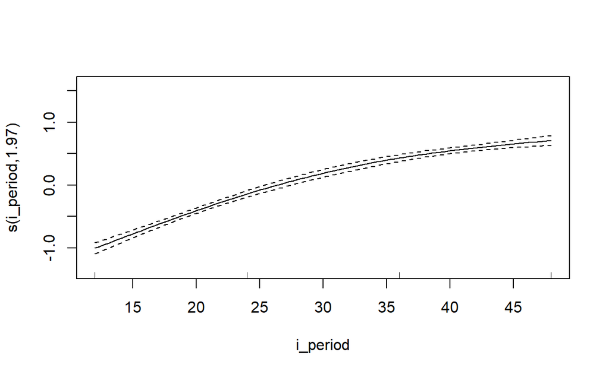

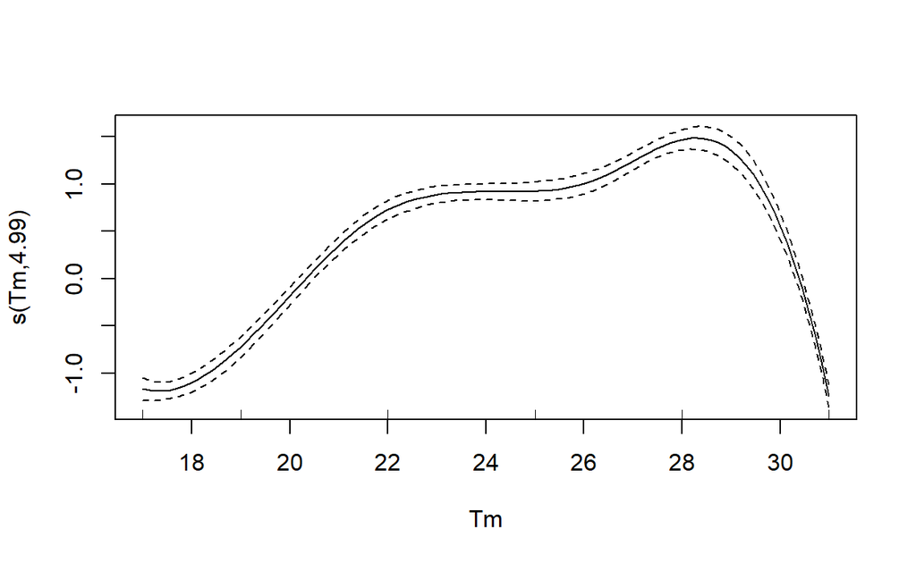

```r
plot(m5)
```

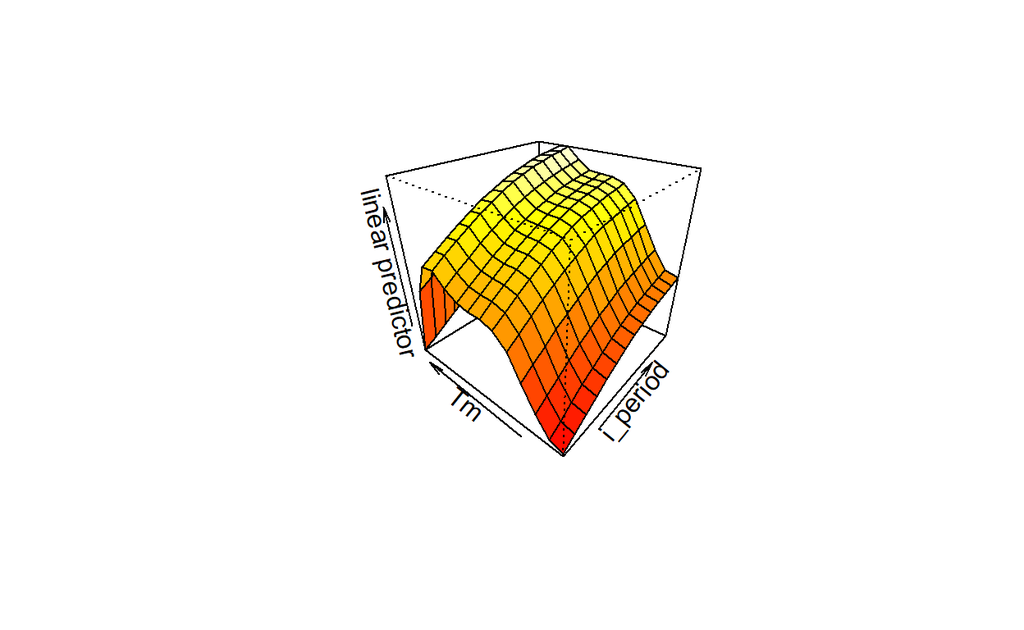

```r
vis.gam(m5,
        theta = -50, # horizontal rotation
        phi = 30, # vertical rotation
        n.grid = max(g_tm$Tm) - min(g_tm$Tm) # grid cells
        )
```

This model has less “wiggliness”, higher R-squared, explained more deviance and has the lowest UBRE score.

Lets compare the models four and five to against each other.

```r
anova(m4,m5, test = "Chisq")
```

```
Analysis of Deviance Table

Model 1: cbind(germ_conidia, non_germ_conidia) ~ s(i_period, k = 3) +
    s(Tm, k = 4, bs = "cp")
Model 2: cbind(germ_conidia, non_germ_conidia) ~ s(i_period, k = 3) +
    s(Tm, k = 6, bs = "ps")
  Resid. Df Resid. Dev Df Deviance  Pr(>Chi)
1    90.001    122.109
2    88.001     97.224  2   24.885 3.948e-06 ***
---
Signif. codes:  0 '***' 0.001 '**' 0.01 '*' 0.05 '.' 0.1 ' ' 1
```

The p-spline model with more knots explained the most deviance and provides a significantly better fit.

And look at the AIC values of all the models.

```r
AIC(m1,m2,m3,m4,m5)
```

```
          df      AIC
m1  5.969536 756.3882
m2 12.907328 716.7909
m3  5.970310 689.6091
m4  5.970871 581.4289
m5  7.963796 560.5300
```

This shows that model five is the best fit, with the lowest AIC and an R squared of 0.9709. Temperature and infection period are significant predictors and the model produces a low UBRE score or 0.179, indicating good predictive ability and less affected by drop one, tests.

Peek at the data

```r
head(g_vpd)
```

```
   RH Tm   vpd i_period rep germ_n non_germ_n
1: 99 28 0.038       12   1     56         44
2: 99 28 0.038       12   2     54         46
3: 99 28 0.038       12   3     52         48
4: 99 28 0.038       12   4     50         50
5: 99 28 0.038       24   1     64         36
6: 99 28 0.038       24   2     65         35
```

```r
str(g_vpd)
```

```
Classes 'data.table' and 'data.frame':  288 obs. of  7 variables:
 $ RH        : int  99 99 99 99 99 99 99 99 99 99 ...
 $ Tm        : int  28 28 28 28 28 28 28 28 28 28 ...
 $ vpd       : num  0.038 0.038 0.038 0.038 0.038 0.038 0.038 0.038 0.038 0.038 ...
 $ i_period  : int  12 12 12 12 24 24 24 24 36 36 ...
 $ rep       : int  1 2 3 4 1 2 3 4 1 2 ...
 $ germ_n    : int  56 54 52 50 64 65 60 63 83 80 ...
 $ non_germ_n: int  44 46 48 50 36 35 40 37 17 20 ...
 - attr(*, ".internal.selfref")=<externalptr>
```

### Visualise the raw data  
Let’s plot the data over time

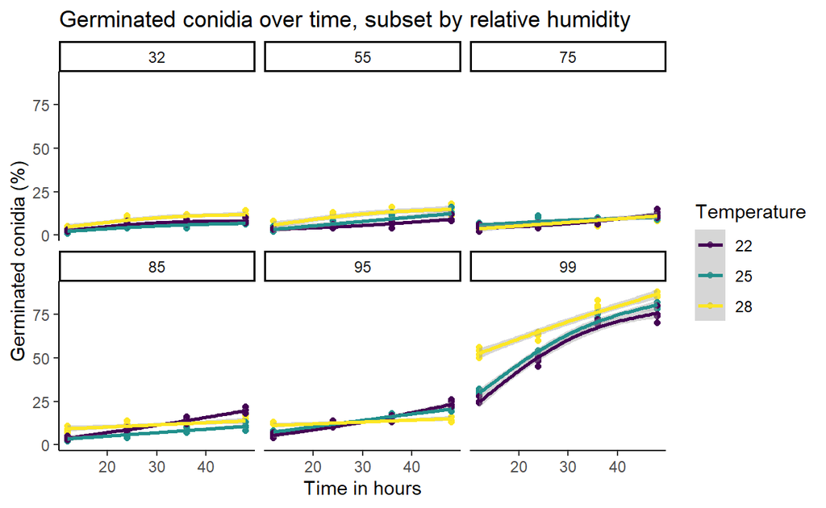

```r
g_vpd |>
   ggplot(aes(x = i_period, y = germ_n, colour = as.factor(Tm))) +
   geom_point()+
   facet_wrap(facets = "RH")+
   geom_smooth(method = "gam",formula = y ~ s(x, k = 3))+
   scale_color_viridis_d()+
   xlab("Time in hours")+
   ylab("Germinated conidia (%)")+
   labs(colour = "Temperature")+
   theme_classic() +
   ggtitle("Germinated conidia over time, subset by relative humidity")
```

```r
   # scale_x_continuous(limits = c(12,48), breaks = c(12,18,24,30,36,42,48))++
   # scale_y_continuous(limits = c(0,100), n.breaks = 5)
```

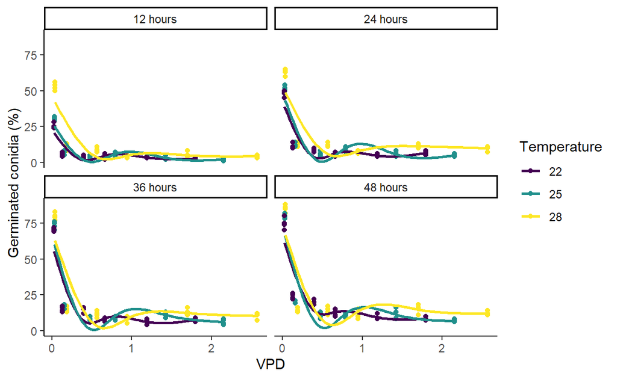

```r
i_p_labs <-c("12 hours","24 hours","36 hours","48 hours")
names(i_p_labs) <- c(12,24,36,48)
g_vpd |>
   ggplot(aes(x = vpd, y = germ_n, colour = as.factor(Tm))) +
   geom_point()+
   facet_wrap(facets = c("i_period"),
              labeller = labeller(i_period = i_p_labs))+
   geom_smooth(method = "gam",formula = y ~ s(x,k=5), se = FALSE)+
   scale_color_viridis_d()+
   xlab("VPD")+
   ylab("Germinated conidia (%)")+
   labs(colour = "Temperature")+
   theme_classic()
```

This data is very hard to fit a curve to and seems like it would benefit with two functions. Lets plot again without the saturated 99% humidity treatment

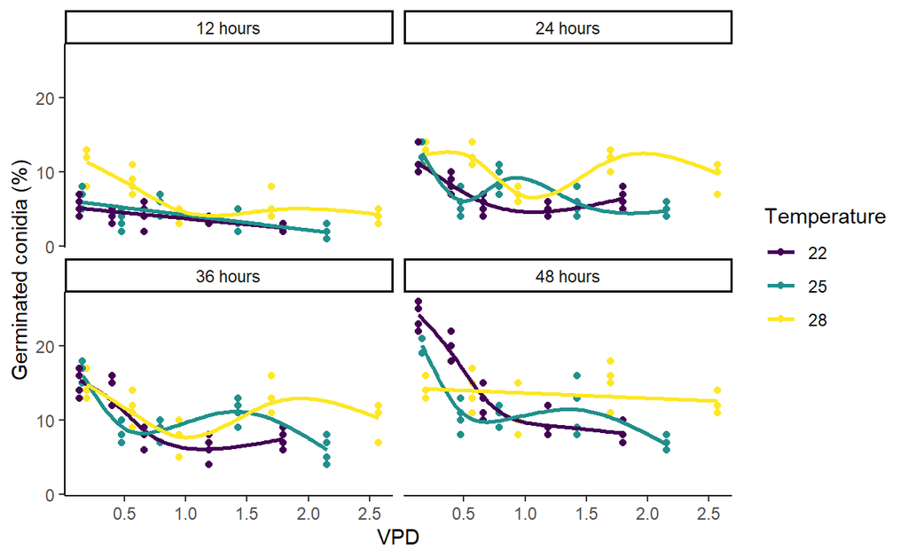

```r
i_p_labs <-c("12 hours","24 hours","36 hours","48 hours")
names(i_p_labs) <- c(12,24,36,48)
g_vpd[g_vpd$RH != 99] |>
   ggplot(aes(x = vpd, y = germ_n, colour = as.factor(Tm))) +
   geom_point()+
   facet_wrap(facets = c("i_period"),
              labeller = labeller(i_period = i_p_labs))+
   geom_smooth(method = "gam",formula = y ~ s(x,k=5), se = FALSE)+
   scale_color_viridis_d()+
   xlab("VPD")+
   ylab("Germinated conidia (%)")+
   labs(colour = "Temperature")+
   theme_classic()
```

From these plots it seems that the influence of VPD on germination is bimodal, with an increase in germination between 1.5 and 2 kPa. Particularly in the warmer treatments

### VPD influence on germination - analysis

```r
m1v <- gam(cbind(germ_n,non_germ_n) ~ s(vpd, k = 5) + s(Tm, k = 3) + s(i_period, k = 3),
           data = g_vpd,
           family = "binomial")
summary(m1v)
```

```
Family: binomial
Link function: logit

Formula:
cbind(germ_n, non_germ_n) ~ s(vpd, k = 5) + s(Tm, k = 3) + s(i_period,
    k = 3)

Parametric coefficients:
            Estimate Std. Error z value Pr(>|z|)
(Intercept) -1.97621    0.02141  -92.31   <2e-16 ***
---
Signif. codes:  0 '***' 0.001 '**' 0.01 '*' 0.05 '.' 0.1 ' ' 1

Approximate significance of smooth terms:
              edf Ref.df Chi.sq p-value
s(vpd)      3.995  4.000 4368.8  <2e-16 ***
s(Tm)       1.911  1.992  160.2  <2e-16 ***
s(i_period) 1.966  1.999  679.6  <2e-16 ***
---
Signif. codes:  0 '***' 0.001 '**' 0.01 '*' 0.05 '.' 0.1 ' ' 1

R-sq.(adj) =  0.834   Deviance explained =   82%
UBRE = 3.5845  Scale est. = 1         n = 288
```

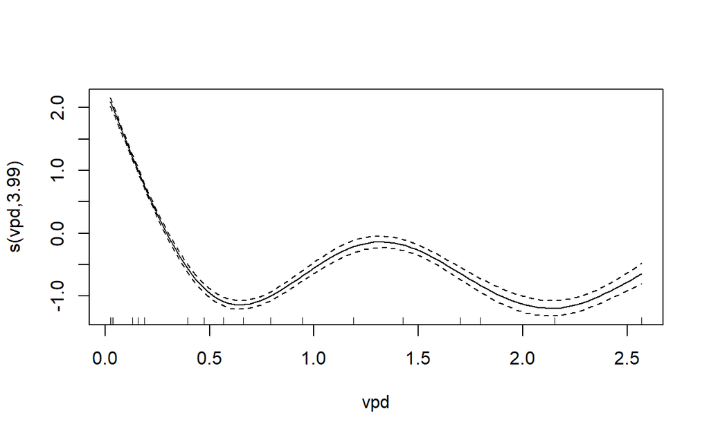

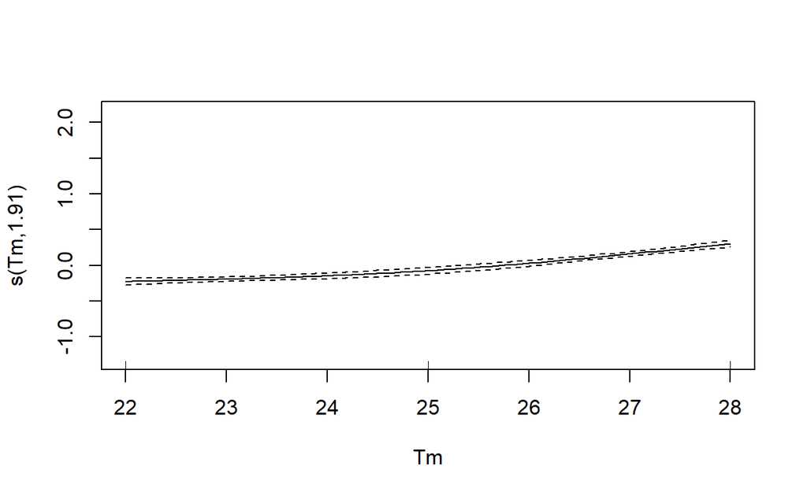

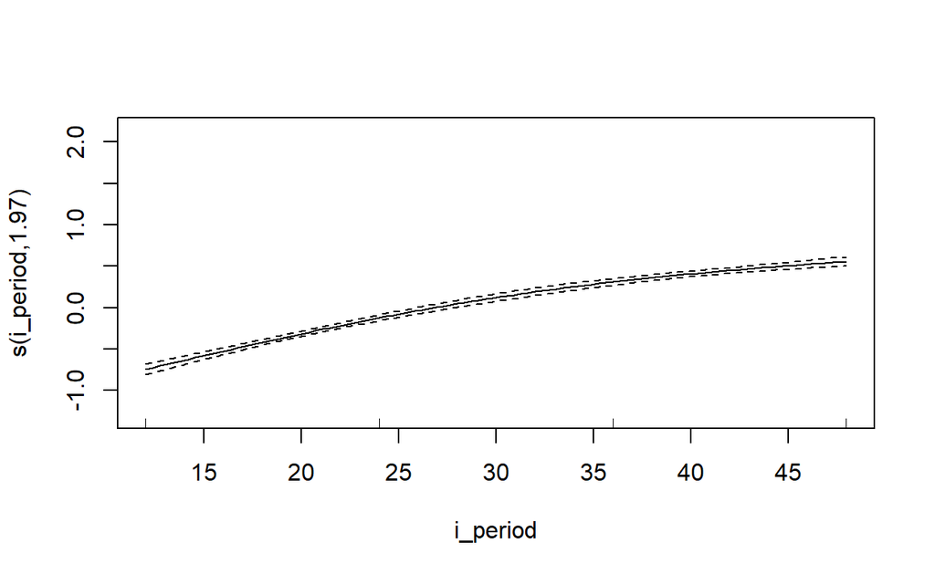

```r
plot(m1v)
```

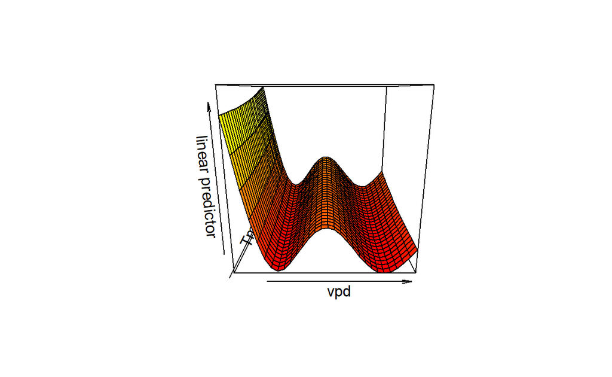

```r
vis.gam(m1v)
```

As earlier, lets try and reduce the wiggliness by using P-splines

```r
m2v <- gam(cbind(germ_n,non_germ_n) ~ s(vpd, k = 5, bs = "ps") + s(Tm, k = 3) + s(i_period, k = 3),
           data = g_vpd,
           family = "binomial")
summary(m2v)
```

```
Family: binomial
Link function: logit

Formula:
cbind(germ_n, non_germ_n) ~ s(vpd, k = 5, bs = "ps") + s(Tm,
    k = 3) + s(i_period, k = 3)

Parametric coefficients:
            Estimate Std. Error z value Pr(>|z|)
(Intercept) -1.98336    0.02141  -92.64   <2e-16 ***
---
Signif. codes:  0 '***' 0.001 '**' 0.01 '*' 0.05 '.' 0.1 ' ' 1

Approximate significance of smooth terms:
              edf Ref.df Chi.sq p-value
s(vpd)      3.996  4.000 4652.8  <2e-16 ***
s(Tm)       1.903  1.991  170.4  <2e-16 ***
s(i_period) 1.968  1.999  693.6  <2e-16 ***
---
Signif. codes:  0 '***' 0.001 '**' 0.01 '*' 0.05 '.' 0.1 ' ' 1

R-sq.(adj) =  0.889   Deviance explained = 86.6%
UBRE = 2.4394  Scale est. = 1         n = 288
```

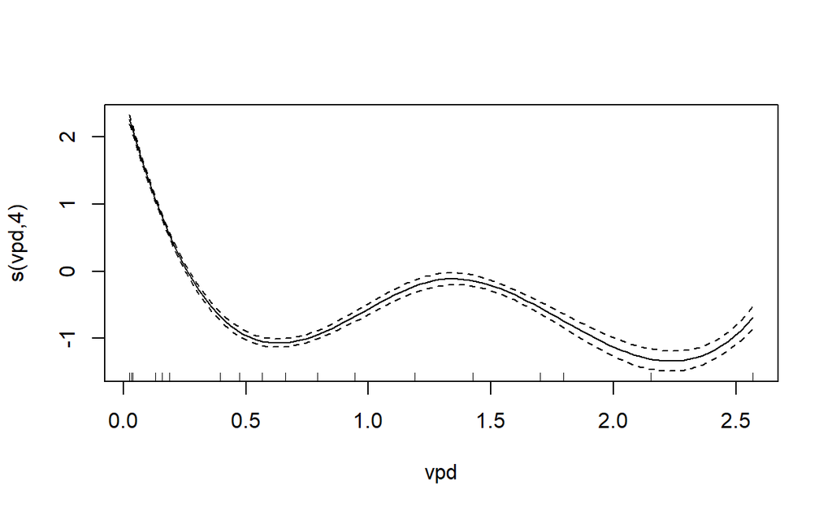

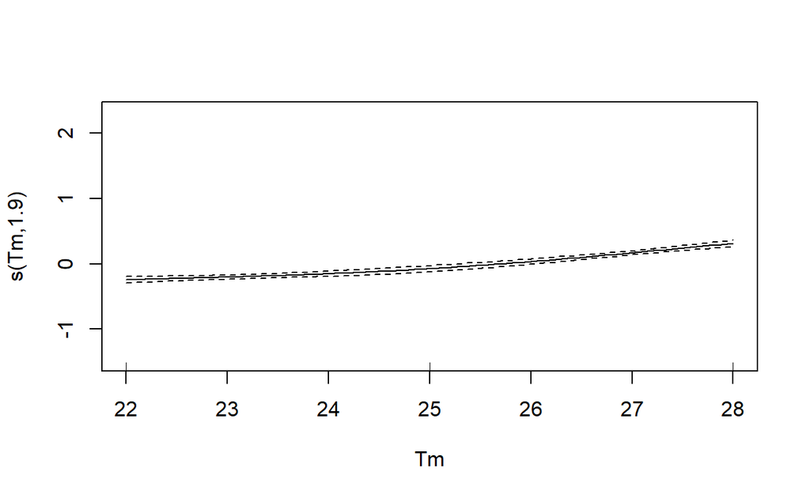

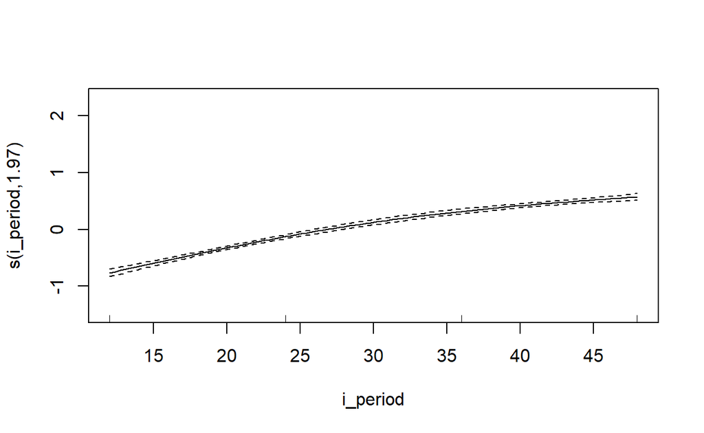

```r
plot(m2v)
```

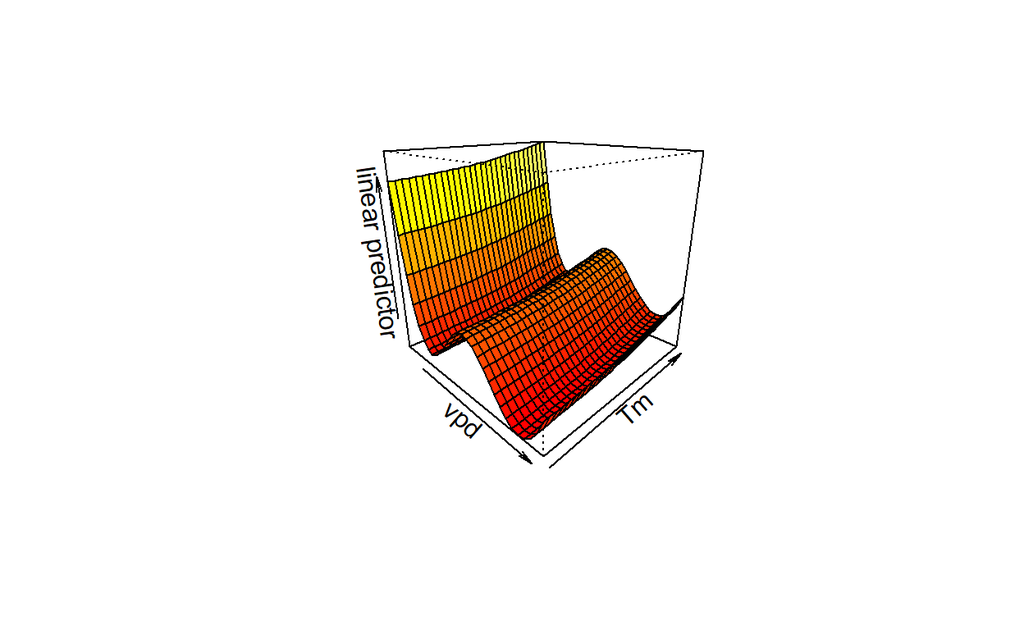

```r
vis.gam(m2v,
        phi = 20,
        theta = 45)
```

There is a better fit and a more decreasing trend in the vpd plot.

Next lets try more vpd knots

```r
m3v <- gam(cbind(germ_n,non_germ_n) ~ s(vpd, k = 8, bs = "ps") + s(Tm, k = 3) + s(i_period, k = 3),
           data = g_vpd,
           family = "binomial")
summary(m3v)
```

```
Family: binomial
Link function: logit

Formula:
cbind(germ_n, non_germ_n) ~ s(vpd, k = 8, bs = "ps") + s(Tm,
    k = 3) + s(i_period, k = 3)

Parametric coefficients:
            Estimate Std. Error z value Pr(>|z|)
(Intercept) -1.95604    0.02115  -92.47   <2e-16 ***
---
Signif. codes:  0 '***' 0.001 '**' 0.01 '*' 0.05 '.' 0.1 ' ' 1

Approximate significance of smooth terms:
              edf Ref.df Chi.sq p-value
s(vpd)      6.802  6.964 5298.8  <2e-16 ***
s(Tm)       1.944  1.996  164.4  <2e-16 ***
s(i_period) 1.972  1.999  724.0  <2e-16 ***
---
Signif. codes:  0 '***' 0.001 '**' 0.01 '*' 0.05 '.' 0.1 ' ' 1

R-sq.(adj) =   0.96   Deviance explained = 94.7%
UBRE = 0.4096  Scale est. = 1         n = 288
```

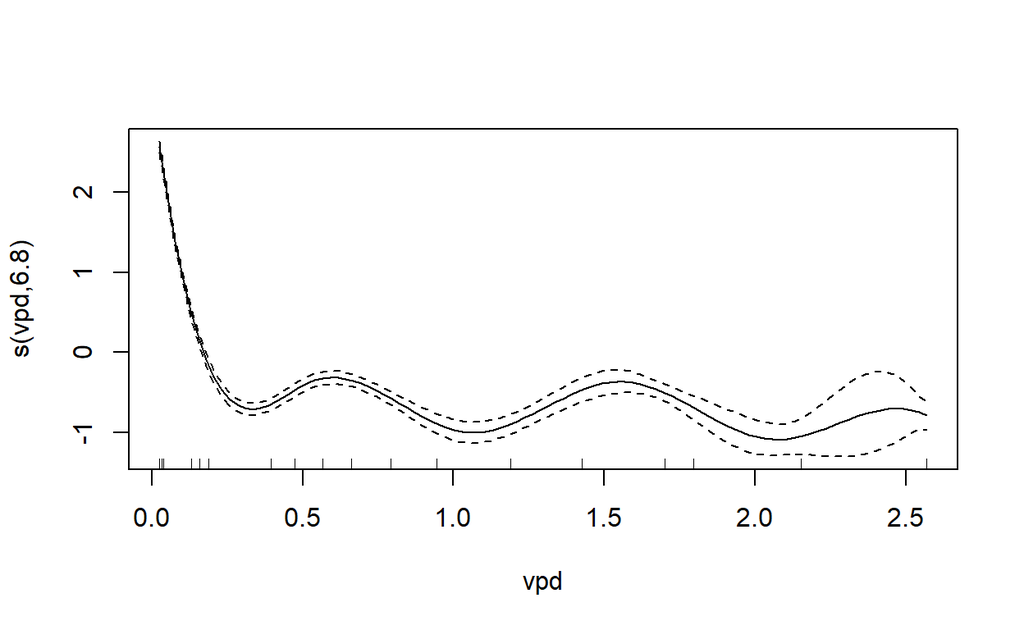

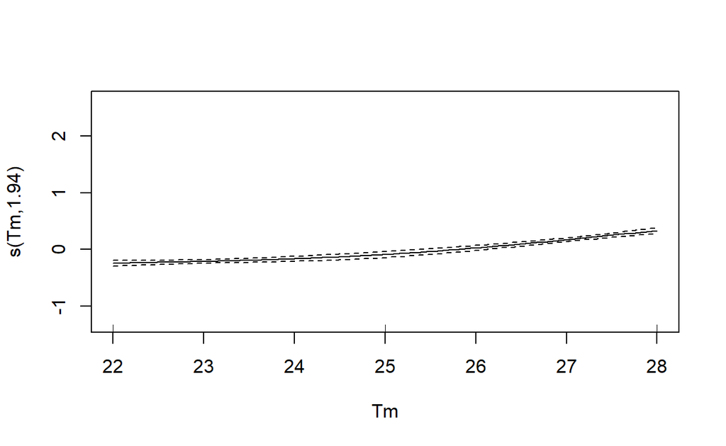

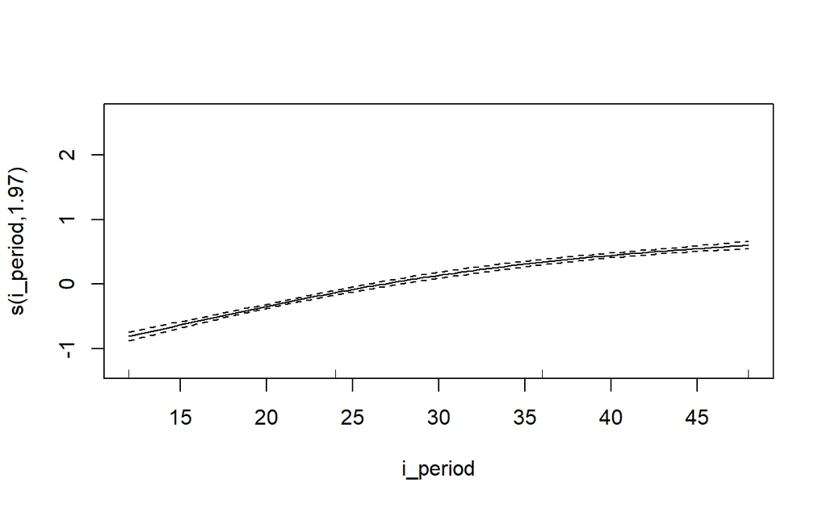

```r
plot(m3v)
```

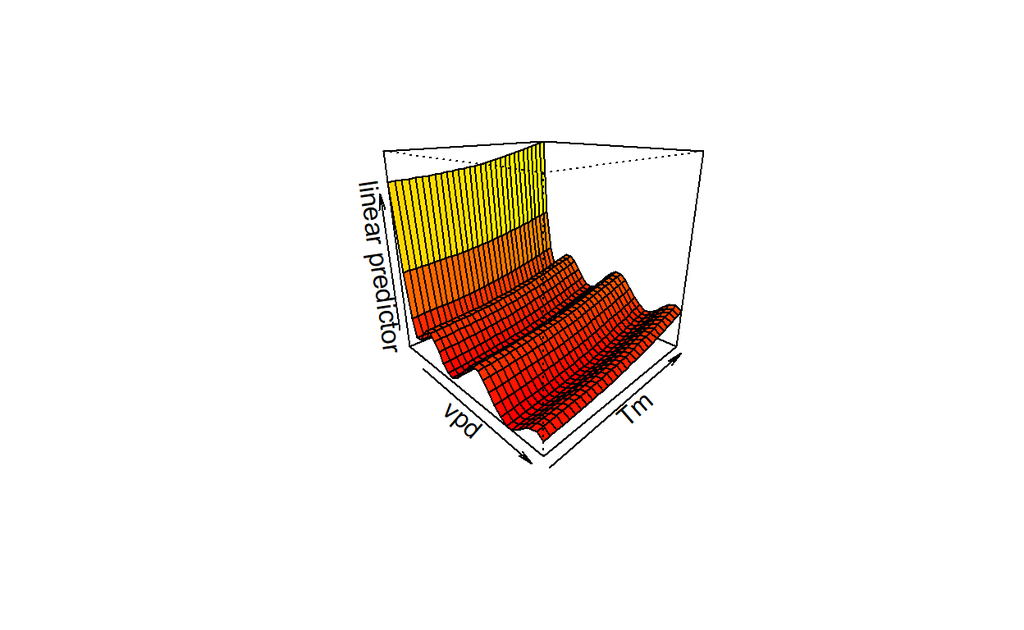

```r
vis.gam(m3v,
        phi = 20,
        theta = 45)
```

[figure not shown]

```r
par(mfrow = c(2,2))
vis.gam(m3v,
        phi = 20,
        theta = 45,
        view = c("vpd","Tm"),
        cond = list(i_period = 12))
vis.gam(m3v,
        phi = 20,
        theta = 45,
        view = c("vpd","Tm"),
        cond = list(i_period = 24))
vis.gam(m3v,
        phi = 20,
        theta = 45,
        view = c("vpd","Tm"),
        cond = list(i_period = 36))
vis.gam(m3v,
        phi = 20,
        theta = 45,
        view = c("vpd","Tm"),
        cond = list(i_period = 48))
```

```r
par(mfrow = c(1,1))
```

While there exists a lot of wiggliness in the gam, the vpd plot shows the increase in germination in at around 1.5 kPa and the rapid decrease in germination between the saturated treatments (0.026 - 0.038 kPa) and the next highest humidity (0.158 - 0.189 kpa). This model also provides a high R-squared (0.9596), low UBRE 0.41, indicating good predictive ability and less affected by drop one, tests.

```r
anova(m2v,m3v)
```

```
Analysis of Deviance Table

Model 1: cbind(germ_n, non_germ_n) ~ s(vpd, k = 5, bs = "ps") + s(Tm,
    k = 3) + s(i_period, k = 3)
Model 2: cbind(germ_n, non_germ_n) ~ s(vpd, k = 8, bs = "ps") + s(Tm,
    k = 3) + s(i_period, k = 3)
  Resid. Df Resid. Dev     Df Deviance
1    279.01     972.80
2    276.04     382.53 2.9699   590.27
```

```r
AIC(m1v,m2v,m3v)
```

```
           df      AIC
m1v  8.872114 2476.188
m2v  8.866634 2146.376
m3v 11.717701 1561.807
```